# Harris Corner Detection

### RE4017 Project 2

#### **Ryan Jennings - 15152324**

## Instructions

Research and implement Harris Corner Detection using Python/Numpy. Investigate the behaviour of the algorithm. Is it rotation invariant? Is it scale-invariant?

Research an appropriate region descriptor for the Harris detector and use it to find correspondence points between pairs of images. Use these correspondences to align the image pairs and generate a composite image.

Report on the performance of your detector using some test image pairs. Suitable test images pairs can be found in the Resources section.

Provide your Python/Numpy code, all input images used, and a short (3-5 page) report in pdf showing the behaviour of your code, with the aligned images shown clearly. Submit your work as a zip file (no .rar files please).

You may work by yourself or in a group with up to two others (max group size is three).

#### Imports

Standard imports for working with images. CV2 and PIL for image handling and matplotlib, numpy and scipy for functions to work on the image data

```python
import cv2

import matplotlib.pyplot as plt
import numpy as np

from PIL import Image
from scipy.ndimage import filters
```

#### Read images into array format

```python
image1 = cv2.imread('arch1.png')
image2 = cv2.imread('arch2.png')
```

#### Images

The first images, two images of the same arch are displayed below. Our objective will be to line up the images then analyse lining up the images with respect to changing scale and rotation.

[figure not shown]

[figure not shown]

```python
plt.figure()
plt.imshow(image1)
plt.title('Arch 1')

plt.figure()
plt.imshow(image2)
plt.title('Arch 2')
```

### Harris Corner Detection Algorithm

#### Find R for thresholding

```python
def harris(im, sigma=3):
    # Performs the Harris corner detector response function
    # derivatives
    imx = np.zeros(im.shape)
    filters.gaussian_filter(im, (1, 1), (0, 1), imx)
    imy = np.zeros(im.shape)
    filters.gaussian_filter(im, (1, 1), (1, 0), imy)

    # compute components of the Harris matrix
    A = filters.gaussian_filter(imx * imx, sigma=2)
    B = filters.gaussian_filter(imx * imy, sigma=2)
    C = filters.gaussian_filter(imy * imy, sigma=2)

    # determinant and trace
    R_determinant = A*C - B**2
    R_trace = A + C

    # Return harmonic mean
    return R_determinant / R_trace
```

#### Find harris interest points

Threshold the points and perform nonmax suppresion

```python
def harris_points(harris_im, min_d=10, threshold=0.1):
    # Python/Numpy code for selecting Harris corner points above a threshold and performing nonmax
    # suppression in a region +/- min_d. “min_d” is the nonmax supression “1/2 width”.

    # (1) Find top corner candidates above a threshold.
    corner_threshold = harris_im.max() * threshold
    harris_im_th = (harris_im > corner_threshold)

    # (2) Find the co-ordinates of these candidates, and their response values
    coords = np.array(harris_im_th.nonzero()).T
    candidate_values = np.array([harris_im[c[0],c[1]] for c in coords])

    # (3) Find the indices into the ‘candidate_values’ array that sort it in order of increasing response strength.
    indices = np.argsort(candidate_values)

    # (4) Store allowed point locations in a Boolean image.
    allowed_locations = np.zeros(harris_im.shape, dtype='bool')
    allowed_locations[min_d:-min_d,min_d:-min_d] = True

    # (5) Select the best points, using nonmax suppression based on the array of allowed locations.
    filtered_coords = []
    for i in indices[::-1]: # Note reversed indices, strongest values are at end of index array.
        r,c = coords[i] # If a point is chosen, blank around it in the ‘allowed_locations’ array.
        if allowed_locations[r,c]:
            filtered_coords.append((r,c))
            allowed_locations[r-min_d:r+min_d+1,c-min_d:c+min_d+1] = False

    return filtered_coords
```

#### Get normalised image patch descriptors

[figure not shown]

We take a small square around the image of pixel size 2(wid) + 1 and flatten it

```python
def get_descriptors(image, filtered_coords, wid=3):
    #return pixel value
    desc = []
    for coords in filtered_coords:
        # Step 1: Align rows into one vector
        patch = image[coords[0]-wid:coords[0]+wid+1,
                      coords[1]-wid:coords[1]+wid+1].flatten()
        # Step 2: Subtract mean value from all elements
        # Step 3: Divide all values of row vector by its norm
        patch = (patch - np.mean(patch))/np.std(patch)
        desc.append(patch)
    return desc
```

#### Matching

Find the pairwise distances and if the value is greater than the threshold add it to the matches array to be returned

```python
def match(desc1, desc2, threshold=1.0):
    n = len(desc1[0])

    # Find pairwise distances
    matches = []
    for i in range(len(desc1)):
        for j in range(len(desc2)):
            ncc_value = sum(desc1[i] * desc2[j]) / (n - 1)
            if ncc_value > threshold:
                matches.append((i, j))
    return matches
```

#### Plot image matches

Attach the images together and draw lines between their matching points

```python
def append_images(im1, im2):
    # The appended images displayed side by side for image mapping
    # select the image with the fewest rows and fill in enough empty rows
    rows1 = im1.shape[0]
    rows2 = im2.shape[0]

    # if elseif statement
    if rows1 < rows2:
        im1 = np.concatenate((im1,zeros((rows2-rows1,im1.shape[1]))), axis=0)
    elif rows1 > rows2:
        im2 = np.concatenate((im2,zeros((rows1-rows2,im2.shape[1]))), axis=0)


    return np.concatenate((im1,im2), axis=1)

def plot_matches(im1, im2, locs1, locs2, matchscores, show_below=True):
    # Plots the matches between both images
    im3 = append_images(im1,im2)
    if show_below:
        im3 = np.vstack((im3,im3))

    plt.figure()
    plt.imshow(im3)

    cols1 = im1.shape[1]
    for i, m in matchscores:
        if m > 0:
            plt.plot([locs1[i][1], locs2[m][1]+cols1], [locs1[i][0], locs2[m][0]], 'c')
    plt.axis('off')
```

```python
def plot_harris_points(im, points):
    plt.figure()
    plt.imshow(im)
    plt.plot([i[1] for i in points], [i[0] for i in points], 'ro')
```

```python
r1 = harris(image1[:,:,0])
filtered_coords1 = harris_points(r1)
d1 = get_descriptors(image1[:,:,0], filtered_coords1, 3)
```

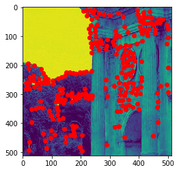

```python
plot_harris_points(image1[:,:,0], filtered_coords1)
```

```python
r2 = harris(image2[:, :, 0])
filtered_coords2 = harris_points(r2)
d2 = get_descriptors(image2[:, :, 0], filtered_coords2, 3)
```

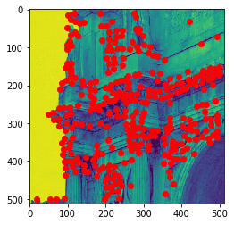

```python
plot_harris_points(image2[:,:,0], filtered_coords2)
```

```python
matches = match(d1, d2)
```

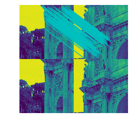

```python
plot_matches(image1[:,:,0], image2[:,:,0], filtered_coords1, filtered_coords2, matches)
```

```python
def ransac(points1, points2, matches, max_dist=1.0):
    # Square of max distance needed for match calculations
    max_squared = max_dist**2
    best_matches = 0
    offsets = np.zeros((len(matches), 2))
    row_offset, col_offset = 1 * 10**6, 1 * 10**6

    for i in range(len(matches)):
        index1, index2 = matches[i]
        offsets[i, 0] = points1[index1][0] - points2[index2][0]
        offsets[i, 1] = points1[index1][1] - points2[index2][1]

    for i in range(len(offsets)):
        match_count = 1.0
        if(offsets[i, 0] - row_offset)**2 + (offsets[i, 1] - col_offset)**2 >= max_squared:
            row_offsets = offsets[i, 0]
            col_offsets = offsets[i, 1]
            for j in range(len(matches)):
                if j != i:
                    if(offsets[i, 0] - offsets[j, 0])**2 + (offsets[i, 1] - offsets[j, 1])**2 < max_squared:
                        row_offsets += offsets[j, 0]
                        col_offsets += offsets[j, 1]
                    match_count += 1.0

        if match_count >= best_matches:
            row_offset = row_offsets / match_count
            col_offset = col_offsets / match_count
            best_matches = match_count

    return row_offset, col_offset

def join_images(im1, im2, row_offset, col_offset):
    width, height = im1.width + abs(int(col_offset)), im1.width + abs(int(row_offset))
    stitched_im = Image.new(im1.mode, (width, height))

    stitched_im.paste(im1, (0, stitched_im.height - im1.height))

    stitched_im.paste(im2, (int(col_offset), stitched_im.height - im1.height + int(row_offset)))

    plt.figure()
    plt.imshow(stitched_im)
    plt.title('Final Stitched Image')
```

```python
row_offset, col_offset = ransac(filtered_coords1, filtered_coords2, matches)
```

[figure not shown]

```python
i1 = Image.open('arch1.png')
i2 = Image.open('arch2.png')
join_images(i1, i2, row_offset, col_offset)
```

The image stitching finally produces a joint image that perfectly lines up the two images. The speed of the program is also suitably fast as higher thresholds allowed for less noise and less points in general to test in the Ransac function

## Testing on Balloon images

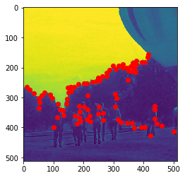

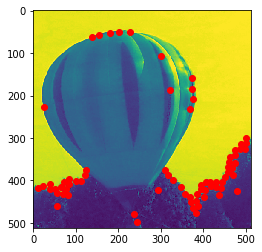

```python
balloon1 = cv2.imread('balloon1.png')
balloon2 = cv2.imread('balloon2.png')

br1 = harris(balloon1[:,:,0])
bfiltered_coords1 = harris_points(br1)
bd1 = get_descriptors(balloon1[:,:,0], bfiltered_coords1, 3)
plot_harris_points(balloon1[:,:,0], bfiltered_coords1)

br2 = harris(balloon2[:,:,0])
bfiltered_coords2 = harris_points(br2)
bd2 = get_descriptors(balloon2[:,:,0], bfiltered_coords2, 3)
plot_harris_points(balloon2[:,:,0], bfiltered_coords2)
```

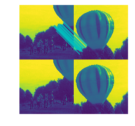

```python
bmatches = match(bd1, bd2)
plot_matches(balloon1[:,:,0], balloon2[:,:,0], bfiltered_coords1, bfiltered_coords2, bmatches)
```

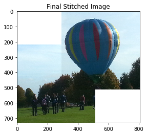

```python
brow_offset, bcol_offset = ransac(bfiltered_coords1, bfiltered_coords2, bmatches)
bi1 = Image.open('balloon1.png')
bi2 = Image.open('balloon2.png')
join_images(bi1, bi2, brow_offset, bcol_offset)
```

Similar to the arch images the test on the balloon images also produces a suitable result that visually looks correct. Again this program runs without large delays from having to test numerous points

## Testing for Rotation Invariance

```python
def test_point_finding(im1, im2):
    im_r1 = harris(im1)
    coords1 = harris_points(im_r1)
    plot_harris_points(im1, coords1)

    im_r2 = harris(im2)
    coords2 = harris_points(im_r2)
    plot_harris_points(im2, coords2)
```

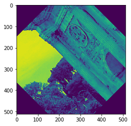

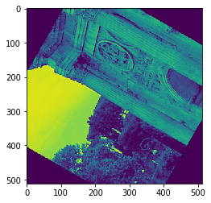

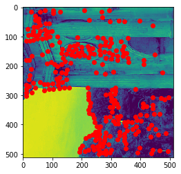

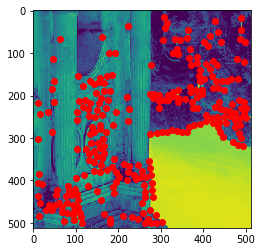

```python
arch1 = np.array(Image.open('arch1.png').convert('L'))
rotated_arch1_45 = np.array(Image.open('arch1.png').convert('L').rotate(45))
rotated_arch1_60 = np.array(Image.open('arch1.png').convert('L').rotate(60))
rotated_arch1_90 = np.array(Image.open('arch1.png').convert('L').rotate(90))
rotated_arch1_180 = np.array(Image.open('arch1.png').convert('L').rotate(180))

test_point_finding(arch1, rotated_arch1_45)
test_point_finding(arch1, rotated_arch1_60)
test_point_finding(arch1, rotated_arch1_90)
test_point_finding(arch1, rotated_arch1_180)
```

When testing for rotation invariance rotating to angles that didn't produce square images were not able to find points. This could be due to facts such as aliasing of the image. The program had no problem with square images such as at 90 and 180 degrees. The points found at 90 and 180 appear to be the exact same despite being upside down or on its side. To stitch these images that are at different angles would go beyond this program as homographic techniques to find how best to scale or wrap the image would be required

## Testing for scale invariance

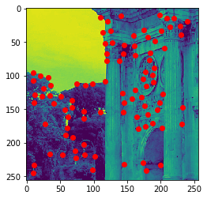

[figure not shown]

```python
img1 = Image.open('arch1.png').convert('L')
larger_arch1 = np.array(img1.resize((int(img1.width*2), int(img1.height*2))))
smaller_arch1 = np.array(img1.resize((int(img1.width*0.5), int(img1.height*0.5))))

test_point_finding(arch1, smaller_arch1)
test_point_finding(arch1, larger_arch1)
```

When testing for scale invariance scaling to a smaller image produced less interest points which is understandable given there is less of the image to find suitable corners in. Unexpectedly the larger image returned no interest points, this could possibly be that the increased size was filled in with blank pixels which threw off the program's ability to find sharp corners